# Workshop Week 7

Author

Affiliation

STAT5003

School of Mathematics and Statistics

# 1 Learning outcomes

**Learning Outcomes**

- To manually construct your own repeated and/or nested cross validation loops for a k-NN model:
  1. Use `createFolds()` from the `caret` package.
  2. Use `knn()` from the `class` package.
  3. Manually code your own CV using `for` loops.

# 2 Workshop preparation

## 2.1 Loading packages

At the start of your R workshop, load all necessary packages to ensure a smooth session. Here’s an example:

```r
library(tidyverse)  # Data science packages
library(ggplot2)    # Data visualization
library(here)       # File paths
library(mlbench)    # Getting the Sonar data set
library(caret)      # Perform Cross-Validation
library(class)      # knn algorithm
```

## 2.2 Data Set

This week, we will be exploring cross validation and its effect on the estimated error.

We will be using the `Sonar` data set and it is included as part of the `mlbench` package. To load the data, do the following:

```r
# Load the mlbench package
# Load the data set
data(Sonar, package = "mlbench")
```

There are two classes where “R” stands for rock (negative class) and “M” stands for metal (positive class). We want to use machine learning models to detect **metal mines (M)**. (By default, `R` determines which one is the positive class according to the alphabetical order.)

# 3 Create a 10-fold cross-validation

Design a 10-fold cross-validation procedure to evaluate a kNN classification model (with $k=5$) accuracy. Use `class::knn()` for implementing a kNN model and use the `caret` package create validation cross fold partitions.

**Visualise Sonar data**

Run the following codes and discuss with your peers to understand what each line aims to do.

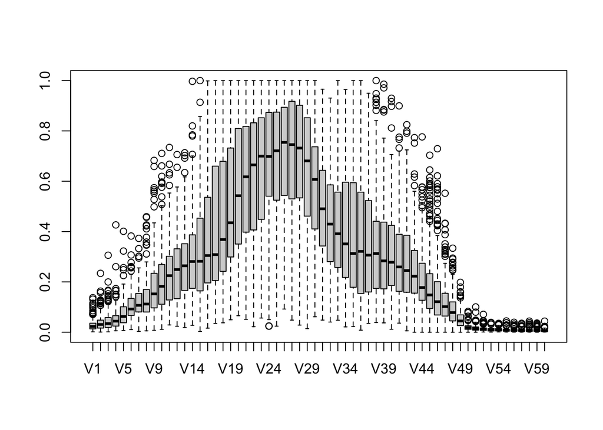

```r
library(caret)
library(MASS)
library(class)

set.seed(5003)

boxplot(Sonar[-61]) # Should we scale?
```

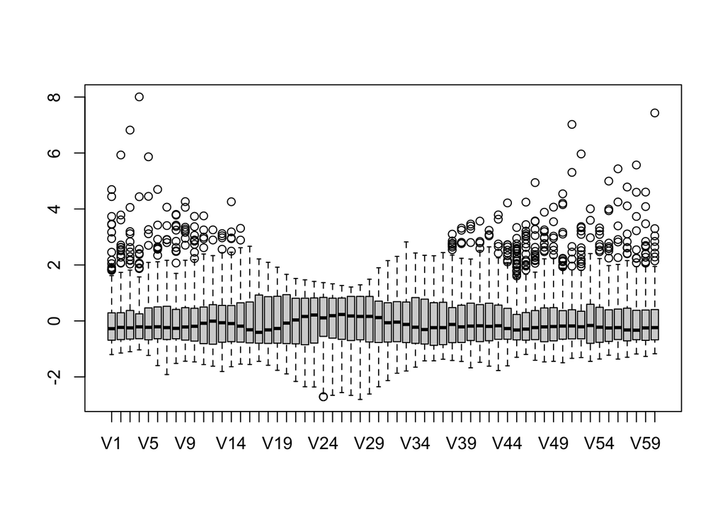

```r
sonar_scaled = Sonar |>
  mutate_if(is.double, .funs = as.numeric) |>
  mutate_if(is.numeric, .funs = scale)

boxplot(sonar_scaled[-61]) # Visualising distribution after scaling.
```

```r
# Splitting into outcome and features
y = sonar_scaled |> pull(Class)
X = sonar_scaled |> dplyr::select(-Class)
n = length(y)
```

**Compute the predicted values on a single sub-fold**

Using the `createFolds()` function of the `caret` package, make the 10 folds you need for your cross validation. Feel free to consult `?createFolds()` to help you with this. Then, working off the template code, fit a `knn` model to one instance of your 10 fold validation, where you train on 90% of the data and test on 10% of the data. Extract the observed and predicted class labels, and output a confusion matrix and the percentage accuracy of your model.

```r
set.seed(5003)
fold <- createFolds(sonar_scaled$Class, k = 10)

# Template code for one instance
test_id = fold$Fold01 # Selecting 10% of the data as test set

X_test = X[test_id, ]
X_train = X[-test_id, ]
y_test = y[test_id]
y_train = y[-test_id]
```

```r
set.seed(5003)
fold <- createFolds(Sonar$Class, k = 10)

# One instance
test_id = fold$Fold01 # Selecting 10% of the data as test set

X_test = X[test_id, ]
X_train = X[-test_id, ]
y_test = y[test_id]
y_train = y[-test_id]

knn5 = knn(train = X_train, test = X_test, cl = y_train, k = 5)
table(knn5, y_test) # Confusion matrix
```

```
    y_test
knn5  M  R
   M 10  0
   R  1  9
```

```r
mean(knn5 == y_test) # Accuracy
```

```
[1] 0.95
```

```r
## alternatively use the built-in function
confusionMatrix(knn5, y_test) ## notice that the algorithm takes "M" as the positive class
```

```
Confusion Matrix and Statistics

          Reference
Prediction  M  R
         M 10  0
         R  1  9

               Accuracy : 0.95
                 95% CI : (0.7513, 0.9987)
    No Information Rate : 0.55
    P-Value [Acc > NIR] : 0.0001114

                  Kappa : 0.9

 Mcnemar's Test P-Value : 1.0000000

            Sensitivity : 0.9091
            Specificity : 1.0000
         Pos Pred Value : 1.0000
         Neg Pred Value : 0.9000
             Prevalence : 0.5500
         Detection Rate : 0.5000
   Detection Prevalence : 0.5000
      Balanced Accuracy : 0.9545

       'Positive' Class : M
```

**Compute the predicted values and accuracy on all sub-folds.**

Now repeat this process on all 10 sub-folds, generating 10 different accuracy scores for each sub fold. Use a `for` loop along with your code from the previous section to accomplish this. Use `k = 5` for your `knn` algorithm. Template code has again, been provided below:

```r
cv_acc = NA  # initialise results vector

for (j in 1:K) {
    test_id = <write your own code>
    X_test = X[test_id, ]
    X_train = X[-test_id, ]
    y_test = <write your own code>
    y_train = <write your own code>
    fit = class::knn(<write your own code>, k = 5)
    cv_acc[j] = <write your own code>
}
```

```r
set.seed(5003)
cv_acc = NA  # initialise results vector
knn.output = NA

for (j in 1:10) {
    test_id = fold[[j]]
    X_test = X[test_id, ]
    X_train = X[-test_id, ]
    y_test = y[test_id]
    y_train = y[-test_id]
    fit = class::knn(train = X_train, test = X_test, cl = y_train, k = 5)
    knn.output[j] = fit
    cv_acc[j] = mean(fit == y_test)

    ## alternatively, can extract from the confusion matrix directly
    ## cv_acc[j] = confusionMatrix(fit, y_test)$overall[1]
}

cv_acc # accuracy from each fold
```

```
 [1] 0.9500000 0.8095238 0.8095238 0.7142857 0.9047619 0.8000000 0.8571429
 [8] 0.8571429 0.8571429 0.8571429
```

```r
mean(cv_acc) # Overall accuracy
```

```
[1] 0.8416667
```

**Compute other performance metrics**

You have now calculated the accuracy of each fold for the kNN classifier. Now, using the predicted and observed values in each case, also calculate the sensitivity, specificity, and $F_1$ score for the kNN classifier. You may use the `caret::confusionMatrix` or an equivalent helper function from another package if you wish.

**For your own understanding, it is recommended to manually calculate these metrics without using a helper function.** Output all of these metrics in a table and identify whether our model has good/bad performance in the metrics.

Template code has been given below:

```r
cv_acc = NA  # initialise accuracy vector
cv_sens = NA  # initialise sensitivity vector
cv_spec = NA  # initialise specificity vector
cv_f1 = NA  # initialise F1 score vector

for (j in 1:10) {
    test_id = <write your own code>
    X_test = X[test_id, ]
    X_train = X[-test_id, ]
    y_test = <write your own code>
    y_train = <write your own code>
    fit = class::knn(<write your own code>, k = 5)
    knn.output[j] = fit
    cv_acc[j] = <write your own code> # Accuracy
    cv_sens[j] = <write your own code> # Sensitivity
    cv_spec[j] = <write your own code> # Specificity
    cv_f1[j] = <write your own code> # F1
}
```

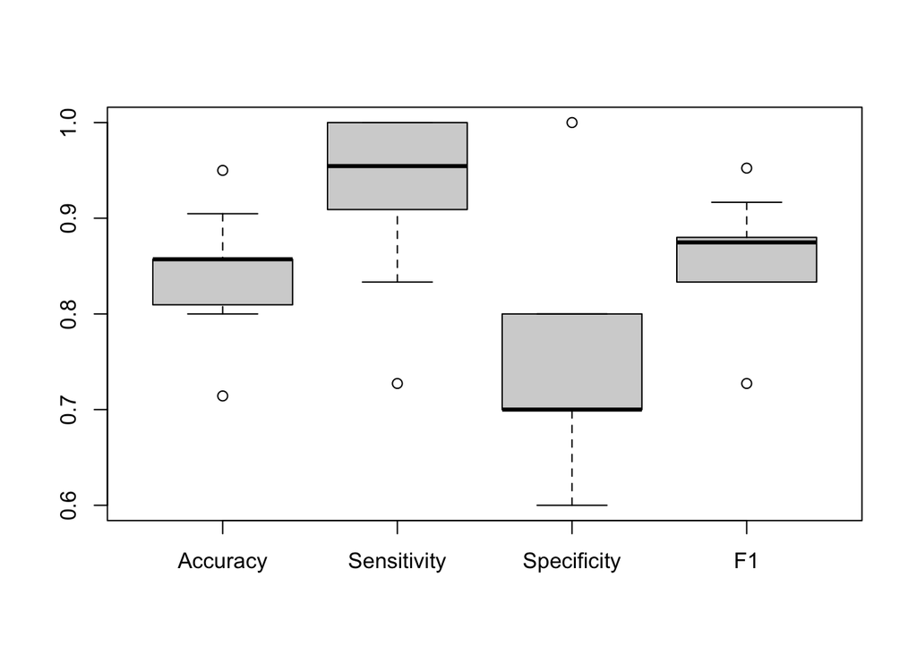

```r
cv_acc = NA  # initialise accuracy vector
cv_sens = NA  # initialise sensitivity vector
cv_spec = NA  # initialise specificity vector
cv_f1 = NA  # initialise F1 score vector

knn.output = NA

set.seed(5003)
## RStudio b default using M as the positive class.
for (j in 1:10) {
test_id = fold[[j]]
X_test = X[test_id, ]
X_train = X[-test_id, ]
y_test = y[test_id]
y_train = y[-test_id]
fit = class::knn(train = X_train, test = X_test, cl = y_train, k = 5)
cv_acc[j] = mean(fit == y_test) # Accuracy
cv_sens[j] = mean(fit == "M" & y_test == "M")/mean(y_test == "M") # Sensitivity
cv_spec[j] = mean(fit == "R" & y_test == "R")/mean(y_test == "R") # Specificity
cv_precision = mean(fit == "M" & y_test == "M")/mean(fit == "M") # Precision (needed to calculate F1)
cv_f1[j] = 2 * (cv_precision * cv_sens[j])/(cv_precision + cv_sens[j])
}


## automatic way via confusionMatrix

for (j in 1:10) {
    test_id = fold[[j]]
    X_test = X[test_id, ]
    X_train = X[-test_id, ]
    y_test = y[test_id]
    y_train = y[-test_id]
    fit = class::knn(train = X_train, test = X_test, cl = y_train, k = 5)
    cv_acc[j] = confusionMatrix(fit, y_test)$overall[1] # Accuracy
    cv_sens[j] =confusionMatrix(fit, y_test)$byClass[1]# Sensitivity
    cv_spec[j] = confusionMatrix(fit, y_test)$byClass[2] # Specificity
    cv_precision = confusionMatrix(fit, y_test)$byClass[5] # Precision (needed to calculate F1)
    cv_f1[j] = confusionMatrix(fit, y_test)$byClass[7]
}


boxplot(cv_acc, cv_sens, cv_spec, cv_f1, names = c("Accuracy", "Sensitivity", "Specificity", "F1"))
```

```r
## library(DT) ## Create nice table
DT::datatable(data.frame(Accuracy = cv_acc,
                         Sensitivity = cv_sens,
                         Specificity = cv_spec,
                         F1 = cv_f1) |> round(2))
```

|  | Accuracy | Sensitivity | Specificity | F1 |
| --- | --- | --- | --- | --- |
| 1 | 0.95 | 0.91 | 1 | 0.95 |
| 2 | 0.81 | 1 | 0.6 | 0.85 |
| 3 | 0.81 | 0.83 | 0.78 | 0.83 |
| 4 | 0.71 | 0.73 | 0.7 | 0.73 |
| 5 | 0.9 | 1 | 0.8 | 0.92 |
| 6 | 0.8 | 0.91 | 0.67 | 0.83 |
| 7 | 0.86 | 1 | 0.7 | 0.88 |
| 8 | 0.86 | 1 | 0.7 | 0.88 |
| 9 | 0.86 | 1 | 0.7 | 0.88 |
| 10 | 0.86 | 0.91 | 0.8 | 0.87 |